# Bayesian Analysis using MCMC simulation with JAGS

Francesco Romeo

April 2021

## Useful libraries & functions

In this preliminary section it has been reported all the used external libraries and some useful functions used to accomplish the outbreak.

```r
# Import libraries
library(readr)
library(readxl)
library(dplyr)
library(ggplot2)
library(ggpubr)
library(R2jags)
library(bayesplot)
library(TeachingDemos)
library(kableExtra)
library(gridExtra)
library(reshape2)
library(viridis)
library(coda)
library(corrplot)
library(animation)
# Create working directories used to store images
dir.create("images", showWarnings = TRUE) # directory to images
dir.create("images/model1", showWarnings = TRUE) # directory to images
dir.create("images/model2", showWarnings = TRUE) # directory to images
```

The **fix.NA()** function is the function used to perform a pre-processing on the acquired data. It takes in input 3 variables:

- *dataset* = is the dataframe to be “cleaned”
- *first* = is the column on which NAs values has to be searched and approximated
- *second* = is an optional variable used to infer the *first* variable if they are correlated.

```r
fix.NA <- function(dataset,first,second=NA){
  candidate <- which(is.na(dataset[first])) # get vector of positions
  delete <- c()
  if (!is.na(second)) { # if second column is passed
    for (elm in candidate){ # iterate over all the found values
      sec <- dataset[second][elm,]
      baseline <- dataset$total_cases[elm]
      if (!is.na(sec)){ # if the second element is not NA
        new_v <- round(abs(dataset$total_cases[elm] - dataset[second][elm,]),0)
        if ((!is.na(new_v)) & (baseline >= new_v )) dataset[first][elm,] <- new_v # substitute the new value
        else delete <- c(delete, elm) # elm to be deleted
      }

      else { # if it is... than compute the value using the median
        get_prov <- dataset$province[elm] # find the prov to use as groupby value
        new_v <- round(mean(c(
          dataset[first][which(dataset$province==get_prov),]
          )[[1]],na.rm=T),0) # get the median value
        if ((!is.na(baseline)) & (dataset$total_cases[elm] >= new_v )) dataset[first][elm,] <- new_v # substitute the new value
        else delete <- c(delete, elm) # elm to be deleted
      }
    }
    print(paste('Warning: ',(length(candidate)-length(delete)),' values have been approximated & ',
                length(delete),' have been candidated...'))
    dataset <- dataset[-delete,] # candidate values

  }
  else {
    dataset <- dataset[-candidate,] # candidate values
    print(paste('Warning: ',length(candidate),' values have been deleted...'))
  }
  return(dataset)
}
```

The **fix.NA.2()** is another function used to perform data cleaning and infer NAs on second dataframe. It takes in input three parameters:

- *dataset* = the dataset to be processed,
- *col.name* = the column on which it is necessary to fix NA values,
- *method* = defines the method to infer the NA values.

```r
fix.NA.2 <- function(dataset,col.name,method='median'){
  col.idx <- grep(col.name, colnames(dataset)) # get index column to use to work only on it
  elm.idx <- which(is.na(dataset[col.name])) # get element indexes where there are NAs
  for (idx in elm.idx){
    province.name <- dataset$province[idx] # get province name to use for group-by
    if (method == 'median'){
      new.value <- median(unlist(dataset[dataset$province==province.name,col.idx], use.names=FALSE),na.rm = T) #get the mean
      dataset[idx,][col.name] = new.value # update dataset with new variable
      print(paste('Warning: ',length(elm.idx),' NAs have been substituted using median...'))
    }
    else{
      new.value <- mean(unlist(dataset[dataset$province==province.name,col.idx], use.names=FALSE),na.rm = T) #get the mean
      dataset[idx,][col.name] = new.value # update dataset with new variable
      print(paste('Warning: ',length(elm.idx),' NAs have been substituted using mean...'))

    }
  }
  return (dataset)
}
```

The **saving()** function has been used to save the images. It takes in input 4 parameters:

- *name* = the name of the image,
- *the.figure* = the object to be saved,
- *w* = is used to customize the width of the image,
- *h* = is used to customize the height of the image.

```r
saving <- function(name,the.figure,w,h){
  png(filename=name, width = w, height = h) # open image
  plot(the.figure)
  dev.off() # close and save image
}
```

## Data Description

The dataset used to perform the Bayesian Analysis comes from the combination of two files scraped on the web. In particular, the two original datasets are described as follow:

- **Ebola datatset:** contains information about Ebola cases occurred in the Democratic Republic of Congo (DRC). The data have been collected by the reported published by DRC Ministry of Health from 22 August 2018 to 22 September 2019. The data are public available on the HUMANITARIAN DATA EXCHANGE (HDX) at the following link: [Ebola Cases and Deaths Outbreak in DRC](https://data.humdata.org/dataset/ebola-cases-and-deaths-drc-north-kivu))
- **Malnutrition dataset:** contains information about the Malnutrition status in the DRC during 2018 and 2019. Also here the data have been collected by the reports released by DRC Ministry of Healt and are public available on the HUMANITARIAN DATA EXCHANGE (HDX) at the following link: [DRC Malnutrition](https://data.humdata.org/dataset/prevalence-de-la-malnutrition-en-rdc/resource/5e155c31-4e19-464d-b0bf-30914d43325f) .

```r
## (1) IMPORT Ebola DATASET
ebola_congo <- (read_csv("dataset/ebola_congo.csv",
                    col_types = cols(`publication_date` = col_skip(), `source` = col_skip(),
                                     `report_date` = col_skip(), `country` = col_skip(),
                                     `confirmed_cases` = col_skip(),
                                     `probable_cases` = col_skip(),
                                     `confirmed_deaths` = col_skip(),
                                     `new_deaths` = col_skip(),
                                     `total_suspected_cases` = col_skip(),
                                     `new_cured` = col_skip(),
                                     `new_suspected_cases` = col_skip(),
                                     `old_suspected_cases` = col_skip(),
                                     `confirmed_cases_change` = col_skip(),
                                     `probable_cases_change` = col_skip(),
                                     `total_cases_change` = col_skip(),
                                     `confirmed_deaths_change` = col_skip(),
                                     `total_deaths_change` = col_skip(),
                                     `total_suspected_cases_change` = col_skip(),
                                     `province` = col_character(),
                                     `total_cases` = col_number(),
                                     `total_deaths` = col_number(),
                                     `total_cured` = col_number()
                                     ))[-1,]) # -1 is used for skip the first line

ebola_congo <- fix.NA(ebola_congo,'total_deaths','total_cured')

### (1.1) grouping by health_zones
congo <- ebola_congo %>% group_by(health_zone) %>%
  summarize(province=first(province), total_cases=sum(total_cases),
            total_deaths=sum(total_deaths), total_cured=total_cases-total_deaths)

congo <- congo[c(-5,-7,-8,-22,-25,-27),] #delete strange health_zones
congo <- congo[congo$total_deaths<=5000,]

## (2) IMPORT Malnutrition DATASET
malnutrition <- read_excel("dataset/malnutrition.xlsx",
                           col_types = c("text", "skip", "skip",
                                         "skip", "text", "text", "numeric",
                                         "skip", "numeric", "numeric", "numeric",
                                         "skip", "skip", "numeric", "skip",
                                         "skip", "skip", "skip", "skip", "numeric",
                                         "skip", "skip", "skip", "skip",
                                         "skip", "skip", "skip",
                                         "skip", "skip", "skip"))

colnames(malnutrition) <- c("province", "health_zone", "postecode",
                             'population_estimate','MAS','MAM','GAM','stunted_growth',
                             'malnutrition_among_FeFAs')

malnutrition$health_zone[malnutrition$health_zone %in% c("Manguredjipa","Nyakunde") ] <- c("Mangurujipa","Nyankunde")

### (2.1) Doing intersection with the health_zones present in congo dataset too
cm_intersection <- intersect(unique(congo$health_zone), unique(malnutrition$health_zone))
malnutrition <- malnutrition[malnutrition$health_zone %in% cm_intersection,][-1]
```

The datasets contain different information about the Ebola epidemic and Malnutrition status in Congo, however not all the gathered data are useful for the analysis, for that reason some of them have been discarded. In particular the final dataset is composed by the following variables:

- **province** = it tells us on which macro-area the data come from. There are 3 macro-areas:
  - *North Kivu*,
  - *Ituri*,
  - *South Kivu*.
- **health_zone** = it gives information about the sub-area. In every macro-area there are different sup-areas; more precisely:
  - for *North Kivu* region there are 9 sup-areas,
  - for *Ituri region* there are 7 sup-areas,
  - for *South Kivu* region there are 1 sup-areas.
- **total_cases** = the number of total cases in each sub-area.
- **total_deaths** = number of total deceases in each sub-area.
- **total_cured** = number of recovered people.
- **postecode** = is the post code of every *healt_zone*
- **population_estimate** = is the estimate of the population in 2018-2019
- **MAM** = stands for “Moderate Acute Malnutrition” and it describes the degree of malnutrition in children from 6 to 59 months of age defined as *Moderate Wasting* (i.e. weight-for-height between –3 and –2 Z-scores of the WHO Child Growth Standards median) and/or mid-upper-arm circumference (MUAC) greater or equal to 115 mm and less than 125 mm [(World Health Organization)](https://www.who.int/elena/titles/food_children_mam/en/).
- **MAS** = stands for “Macrophage activation syndrome” and it is a severe, potentially life-threatening, complication of several chronic rheumatic diseases of childhood. It occurs most commonly with systemic-onset juvenile idiopathic arthritis (SoJIA) [(MAS-Wikipedia)](https://en.wikipedia.org/wiki/Macrophage_activation_syndrome).
- **GAM** = Global Acute Malnutrition (GAM) is a measurement of the nutritional status of a population that is often used in protracted refugee situations. Along with the Crude Mortality Rate, it is one of the basic indicators for assessing the severity of a humanitarian crisis [(GAM-Wikipedia)](https://en.wikipedia.org/wiki/Global_Acute_Malnutrition).
- **stunted_growth** = Stunting is the impaired growth and development that children experience from poor nutrition, repeated infection, and inadequate psychosocial stimulation. Children are defined as stunted if their height-for-age is more than two standard deviations below the WHO Child Growth Standards median [(World Health Organization)](https://www.who.int/news/item/19-11-2015-stunting-in-a-nutshell).
- **malnutrition_among_FeFAs** = stands for “Iron(Fe) for Adolescence” and it is a new indicator to address malnutrition among adolescents. Iron deficiency anemia is the major cause of mortality. [(Fe-Wikipedia)](https://en.wikipedia.org/wiki/Iron-deficiency_anemia).

The code below has been used to merge the two data frames: *congo* and *malnutrition*

```r
#perform the join
congo <- left_join(congo, malnutrition, by = "health_zone")

### find NAs and infer them using group median:

col.numeric<- unlist(lapply(congo, is.numeric)) # get only numeric cols
# Getting the columns of A that have at least 1 NA is equivalent to get the rows that have at least NA for t(A).
col.names <- colnames(congo[col.numeric])[!complete.cases(t(congo[col.numeric]))] # complete.cases by definition (very efficient since it is just a call to C function) gives the rows without any missing value.
for (name in col.names) congo <- fix.NA.2(congo, name) # fix NAs
```

[output not shown]

Table 1: Summary Numerical Variables:

| Var | Min. | Q1. | Median | Mean | Q3. | Max. |
| --- | --- | --- | --- | --- | --- | --- |
| total cases | 34.0 | 657.0 | 1209.0 | 2629.00 | 5562.0 | 8889.0 |
| total deaths | 0.0 | 241.0 | 685.0 | 1215.00 | 1711.0 | 4403.0 |
| total cured | 1.0 | 147.0 | 631.0 | 1414.00 | 1482.0 | 7146.0 |
| MAS | 0.3 | 1.9 | 1.9 | 2.59 | 3.4 | 6.1 |
| MAM | 2.4 | 2.7 | 2.7 | 4.00 | 5.1 | 10.9 |
| GAM | 2.8 | 4.6 | 4.6 | 6.64 | 10.2 | 14.3 |
| stunted_growth | 47.1 | 49.6 | 49.6 | 53.51 | 55.2 | 72.4 |
| malnutrition_among_FeFAs | 0.2 | 0.2 | 0.2 | 0.69 | 1.3 | 1.3 |
| population_estimate | 48003.0 | 126776.0 | 161232.0 | 200370.00 | 264633.0 | 462362.0 |

### Graphic Representation

The code reported has been used to generate **Figure 1**,that shows a graphic representation of 2 numerical variables: *total_cases, and total_deaths* . The *group.colors* variable has been used to manually set the colors of the histograms in order to make the understanding easier.

```r
# (0) Set Colors
group.colors <- c('Ituri' = "royalblue3",
                  'North Kivu' = "tomato2", 'South Kivu' ="gold1")

# (1) DEATHS' HISTOGRAMS

## (1.1) Deaths Histogram based on "provinces"
deaths_prov <- congo %>% ggplot(aes(x=total_deaths, fill=province)) +
  geom_histogram(binwidth=500,colour = 'purple',
                 alpha=.6,boundary = 0, closed = "right") +
  scale_fill_manual(values=group.colors) +
  ylim(0,7)+
  scale_x_discrete(name=" ",limits= seq(0,4500,500)) +
  labs(title = 'Total deaths',y=' ') +
  theme(legend.position = c(.88, 0.65),
        axis.text.y = element_text(colour='red'),
        axis.line.y = element_line(size = 1, colour = "red"),
        plot.title = element_text(hjust = 0.5, size = 14, color = 'purple'))

## (1.2) Purple Histogram
deaths_h <- congo %>% ggplot(aes(x=total_deaths)) +
  geom_histogram(binwidth=500, fill= 'orchid',colour = 'purple',
                 alpha=.6,boundary = 0, closed = "left") +
  ylim(0,7)+
  xlim(0, 5000) +
  scale_x_discrete(name=" ",limits= seq(0,4500,500)) +
  labs(y=' ') +
  theme(axis.text.y = element_text(colour='red'),
        axis.line.y = element_line(size = 1, colour = "red"))

## (1.3) Purple Histogram + Density
deaths_d <- congo %>% ggplot(aes(x=total_deaths)) +
  geom_histogram(aes(y=..density..), binwidth=500,
                 fill= 'orchid',colour = 'purple',
                 alpha=.6,boundary = 0, closed = "left") +
  xlim(0, 5000) +
  ylim(0,10e-04)+
  geom_density(fill='red',alpha=.2,col='violet') +
  scale_x_discrete(name=" ",limits= seq(0,4500,500)) +
  labs(y='Densities') +
  theme(plot.title = element_text(hjust = 0.5, size = 14, color = 'purple'),
        axis.title.y = element_text(size=12,colour = 'black',face='bold'),
        axis.line.y = element_line(size = 1, colour = "black"),
        axis.text.y = element_text(colour='black'))

# (2) CASES' HISTOGRAMS

## (2.1) Cases Histogram based on "provinces"
cases_prov <- congo %>% ggplot(aes(x=total_cases, fill=province)) +
  geom_histogram(binwidth=1000,colour = 'darkgreen',
                 alpha=.6,boundary = 0, closed = "right") +
  scale_fill_manual(values=group.colors) +
  scale_x_discrete(name=" ",limits= seq(0,9000,1000)) +
  ylim(0,7)+
  labs(title = 'Total cases',y=' ') +
  theme(legend.position = c(.88, 0.65),
        axis.text.y = element_text(colour='red'),
        axis.line.y = element_line(size = 1, colour = "red"),
        plot.title = element_text(hjust = 0.5, size = 14, color = 'darkgreen'))

## (2.2) Green Histogram
cases_h <- congo %>% ggplot(aes(x=total_cases)) +
  geom_histogram(binwidth=1000, fill= 'cyan4',colour = 'darkgreen',
                 alpha=.6,boundary = 0, closed = "left") +
  ylim(0,7)+
  scale_x_discrete(name=" ",limits= seq(0,9000,1000)) +
  labs(y=' ') +
  theme(axis.text.y = element_text(colour='red'),
        axis.line.y = element_line(size = 1, colour = "red"))

## (2.3) Green Histogram + Density
cases_d <- congo %>% ggplot(aes(x=total_cases)) +
  geom_histogram(aes(y=..density..), binwidth=1000,
                 fill= 'cyan4',colour = 'darkgreen',
                 alpha=.6,boundary = 0, closed = "left") +
  xlim(0, 5000) +
  ylim(0,10e-04)+
  geom_density(fill='green',alpha=.2,col='seagreen1') +
  scale_x_discrete(name=" ",limits= seq(0,9000,1000)) +
  labs(y=' ') +
  theme(plot.title = element_text(hjust = 0.5, size = 14, color = 'darkgreen'),
        axis.line.y = element_line(size = 1, colour = "black"),
        axis.text.y = element_text(colour='black'))
```

Encapsulate the 6 plots into one figure object and save it.

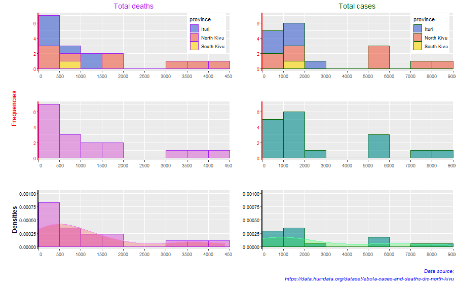

**Figure 1: Summary Histograms**

```r
figure <- ggarrange(deaths_prov, cases_prov,
                    deaths_h, cases_h,
                    deaths_d, cases_d,
                    ncol = 2, nrow = 3, align = 'hv')

annotaded_fi <- annotate_figure(figure,
                bottom = text_grob("Data source: \n https://data.humdata.org/dataset/ebola-cases-and-deaths-drc-north-kivu",
                                   color = "blue", hjust = 1.01, x = 1,
                                   face = "italic", size = 10),
                left = text_grob("Frequencies", color = "red", size=12,
                                 rot = 90, face='bold', hjust = -.4,
                                 vjust = 2.3),
                fig.lab = " ", fig.lab.face = "bold")

annotaded_fi
saving('images/death_cases_histogram.jpg',annotaded_fi,w=900,h=556)
```

## 1) Model 1

In this first model, independence among each death probabilities has been assumed among each sub-area. In order to model the outcome, a Binomial distribution has been used. The total number of infected people per each sub area $i$ has been denoted with $n_{i}$. The total number of deceased people is represented by $r_{i}$ which is a binary response variable with “true” probability $p$.

$$r_i \sim Binomial(p,n_i)$$

A $Beta(0.5,0.5)$ distribution has been used as standard-non-informative prior for $p$. The Beta distribution is a continuous distribution taking values in the domain $0-1$ with two shape parameters $(\alpha, \beta) \in \mathbb{R}^{+}\times\mathbb{R}^{+}$.

$$p \sim Beta(0.5, 0.5)$$

In order to make inference on the $p$ the model has been written to be compatible in JAGS (Just Another Gibbs Sampler).

### 1.1) JAGS Model 1

Since JAGS does not deal with dataframes it has been necessary to store all the required variables into lists.

```r
n <- congo$total_cases # tries
r <- congo$total_deaths # number of success (unfortunately...)
N <- nrow(congo)
congo.jags <- list("r", "n", "N")
```

```r
# Model
model <- function() {
  for(i in 1:N){
    r[i] ~ dbinom(p, n[i]) #  Likelihood
  }
  p ~ dbeta(.5, .5) # Prior
}

# Starting values
mod.inits = function(){
  list("p" = rbeta(1, 1/2, 1/2))
}

# Run JAGS
set.seed(1618216)
mod.fit <- jags(data = congo.jags,
                model.file = model, inits = mod.inits,
                parameters.to.save = c("p"),
                n.chains = 3, n.iter = 1e4, n.burnin = 1000, n.thin=5)
```

### 1.2) Output & Convergence Diagnostic

```r
mod.fit
```

```
## Inference for Bugs model at "C:/Users/Francesco/AppData/Local/Temp/RtmpwDw98i/model288c551f51ee.txt", fit using jags,
##  3 chains, each with 10000 iterations (first 1000 discarded), n.thin = 5
##  n.sims = 5400 iterations saved
##            mu.vect sd.vect      2.5%       25%       50%       75%     97.5%
## p            0.462   0.002     0.458     0.461     0.462     0.464     0.467
## deviance 10089.413   1.446 10088.390 10088.498 10088.861 10089.760 10093.476
##           Rhat n.eff
## p        1.001  5400
## deviance 1.003  5400
##
## For each parameter, n.eff is a crude measure of effective sample size,
## and Rhat is the potential scale reduction factor (at convergence, Rhat=1).
##
## DIC info (using the rule, pD = var(deviance)/2)
## pD = 1.0 and DIC = 10090.5
## DIC is an estimate of expected predictive error (lower deviance is better).
```

Is it possible to rely on this output? Since it is well known the closed form for the posterior, it is possible to use the Bayesian Conjugate Model to double check the output:

$$\begin{aligned}
L(r|n,p) &= {\displaystyle \prod_{i=1}^{17} Bin(r_{i}|n_{i},p)} \\
\pi(p) &= Beta(\alpha,\beta),\\
\pi(p|r,n) &= Beta(\alpha+\sum_{i=1}^{17}r_{i},
\beta+ \sum_{i=1}^{17}n_{i}- \sum_{i=1}^{17}r_{i})\\
&= Beta(\alpha^{*},\beta^{*})\\
\hat{p} &= E_{\pi(\cdot|r,n)} [p] = \frac{\alpha^{*}}{\alpha^{*}+\beta^{*}}
\end{aligned}$$

```r
# Jeffrey's prior
alpha <- 1/2
beta <- 1/2

# Conjugate inference

alpha.star <- alpha+sum(r)
beta.star <- alpha+sum(n)-sum(r)

# Point estimation
p.hat.c <- alpha.star/(alpha.star+beta.star)
cat(
  paste("- `", "Conjugate Inference: ",round(p.hat.c,7), "`"),
  paste("- `", "JAGS Inference: ",0.4621742, "`"),
  sep='\n'
)
```

- `Conjugate Inference: 0.4621143`
- `JAGS Inference: 0.4621742`

Well, the two $p$ are almost the same, so the output returned by JAGS seems to be reasonable. Even thought the probability of death seems to be very high and this is not actually a good discovery.

Now it is the time to control if the MCMC performed on JAGS can be trusted or not. One way is to look at the chains and see if they are stationary (i.e if the simulated parameters are going in a consistent direction). In order to do that, it is necessary to extract the data from model outputs (this can be performed by going inside the **JAGS output** and retrieve the **sims.array** ) and then use different plot representation to inspect sampling behavior and assess convergence.

```r
chainArray <- mod.fit$BUGSoutput$sims.array # get the chain
```

#### 1.2.1) TracePlot & Gelman-Rubin

A useful diagnostic plot is the trace plot, which actually is a time series plot of the Markov chains. In the trace plot it is possible to see the evolution of the parameter vector over the iterations of one or many Markov chains. If a chain is stationary, it should be showing any long-term trends, meaning that the average value of the chain should be almost flat. Therefore, by looking at **Figure 2**, it seems so. This means that if one tries, for example, to estimate $p$ by using the first 500 iterations he/she is going to get a similar result that he/she would have got if has tried to estimate the $p$ by using, for example, iterations from 1000 to 1500. Moreover, it also seems that all the chains explore the same region of parameter values and this can be infer by the fact that all the chains lie on top of each other.

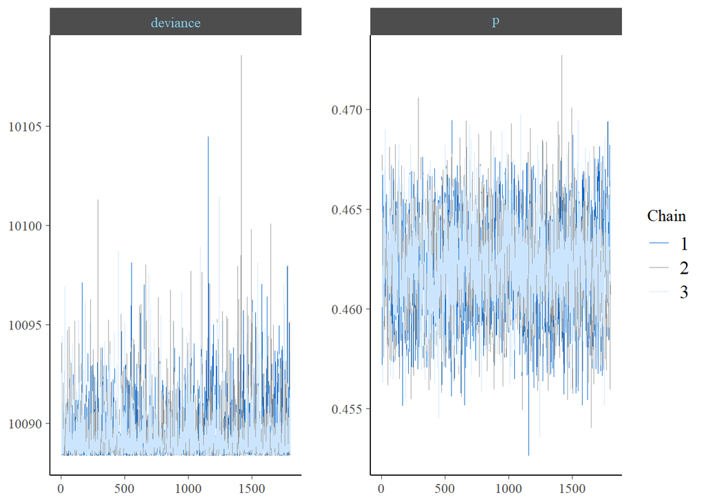

**Figure 2: Trace Plot**

```r
# this is variable is used to change the aspect of some plots.
myfacets <-
  facet_bg(fill = "gray30", color = NA, ) +
  facet_text(face = "bold", color = "skyblue", size = 10)

# (1) mcmc_trace
color_scheme_set("mix-brightblue-gray")
## (1.1) plot first 4 p_{i}
mcmc_trace(chainArray, facet_args = list(labeller = ggplot2::label_parsed)) +
  myfacets
```

However, since the plot is still too confused, it could help our diagnostic to have a closer look at it by using the *“window”* parameter inside the *“mcmc_trace function”* and see how every chain behaves. As **Figure 3** shows, it seems that the chains spend substantial time in the same region of the parameter space, sign that they are reaching stationary.

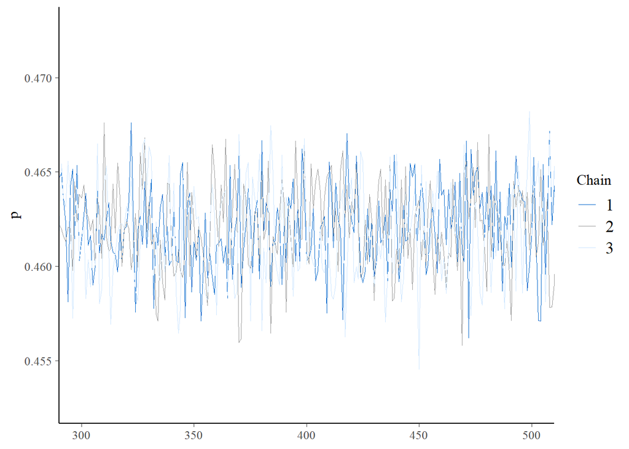

**Figure 3: Trace Plot**

```r
mcmc_trace(chainArray, pars = "p", window = c(300,500),
           facet_args = list(labeller = ggplot2::label_parsed))+
  myfacets
```

Since **Trace PLots** provide an informal diagnostic about the convergence of the chains, it is better to rely on another diagnostic called **Gelman & Rubin diagnostic**. This diagnostic calculates the variability within the chains and compares that to the variability between the chains [(Gelman & Rubin)](https://blog.stata.com/2016/05/26/gelman-rubin-convergence-diagnostic-using-multiple-chains/). The diagnostic can be computed by calling the **gelman.diag()** function implemented in the **coda library**. The **Potential Scale Factor** is the statistics that tells about the chain convergence. The closer it is to 1 the better the convergence is. Values faraway from 1 indicate that the chains haven’t reached yet convergence.

```r
coda.fit <- as.mcmc(mod.fit)
gelman.diag(coda.fit)
```

```
## Potential scale reduction factors:
##
##          Point est. Upper C.I.
## deviance       1.01       1.01
## p              1.00       1.00
##
## Multivariate psrf
##
## 1
```

As it possible to see from the above output, the chains reached convergence since this value is 1. It is also possible to plot this diagnostic by using the **gelman.plot()** function. It shows how the “*shrinkage factor*” changes once iterations are added to the chains. As can be seen, after $6000$ we are almost sure to have reached convergence.

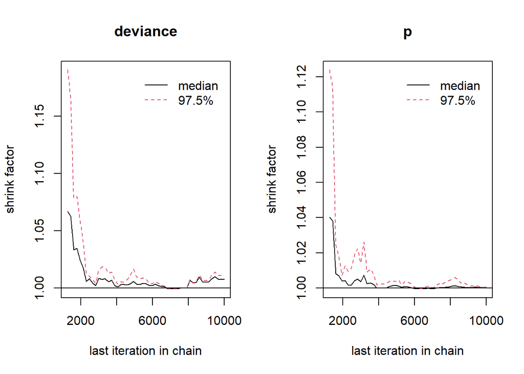

**Figure 4: Gelman-Rubin Plot**

```r
gelman.plot(coda.fit)
```

#### 1.2.2) Autocorrelation

Another relevant diagnostic analysis can be done by checking the autocorrelation plots. Autocorrelation is number between -1 and 1 and it measures how “*linearly dependent*” the current values of the chains are to past values (== Lags). See Appendix A for autocorrelation explanation.

```r
autocorr.diag(coda.fit)
```

```
##             deviance             p
## Lag 0    1.000000000  1.0000000000
## Lag 5    0.002235006  0.0281204634
## Lag 25   0.010680880 -0.0040624242
## Lag 50  -0.007026580  0.0005666977
## Lag 250 -0.008168855  0.0186056427
```

In fact, by calling the previous function we see that at the $5^{th}$ lag the autocorrelation for $p$ already goes to zero. Autocorrelation is very important because it tells us how much information is available in each Markov chain. Sampling $1e4$ iteration from a highly correlated Markov chain yields less information about the stationary distribution than we would obtain from $1e4$ independently drawn from the stationary distribution.

It is possible to visualize the autocorrelation by calling the **mcmc_acf()** function. This function shows the autocorrelation for each Markov chain separately up to a user-defined number of lags. What is expected is to see a low autocorrelation since it is a signal of convergence. As it is possible to see from **Figure 5**, the autocorrelation function drops to 0 pretty fast after only a couple of lags.

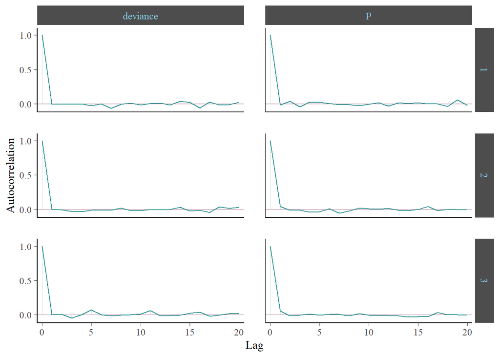

**Figure 5: Autocorelation Plots**

```r
# (2) mcmc_acf
color_scheme_set("mix-teal-pink") # set color

mcmc_acf(chainArray, facet_args = list(labeller = ggplot2::label_parsed))+
  myfacets
```

#### 1.2.3) Posterior Distributions

Another diagnostic analysis can be done by taking a look at the plots of estimated density of the parameters and of the deviance, where density plots are just smoothed histograms of the samples. These are shown in **Figure 6** reported here below.

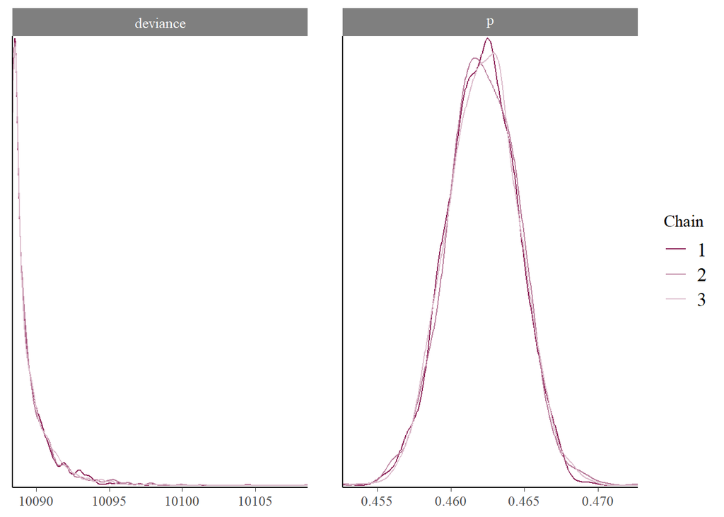

**Figure 6: Density Overlay Plot**

```r
# (3) mcmc_density
color_scheme_set("pink")
myfacets <-
  facet_bg(fill = "gray50", color = NA, ) +
  facet_text(face = "bold", color = 'white', size = 10)

mcmc_dens_overlay(chainArray, facet_args = list(labeller = ggplot2::label_parsed)) +
  myfacets
```

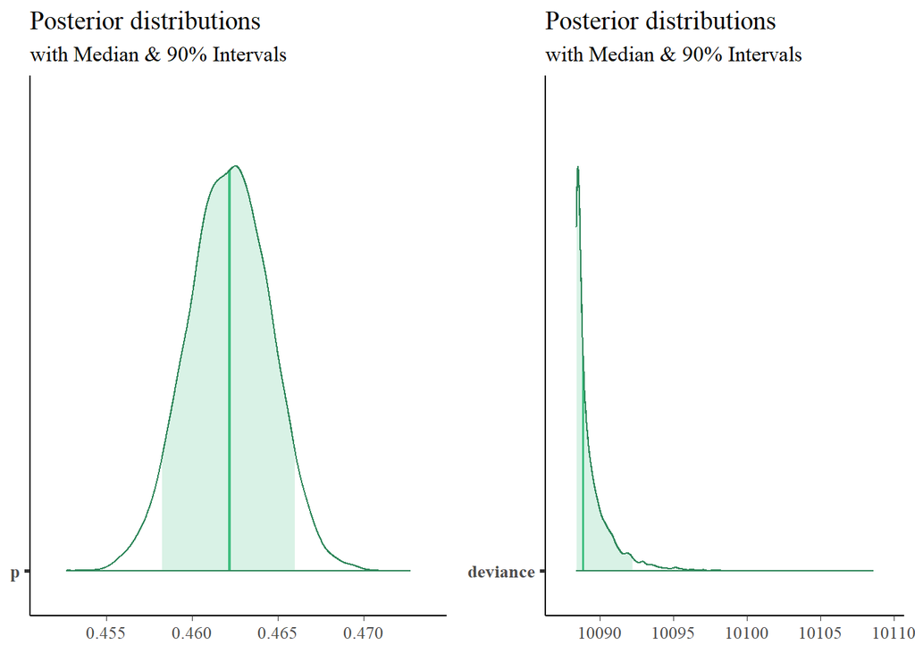

Figure 7: Posterior Density Plot

```r
# (4) areas plot
color_scheme_set("green")
plot_title <- ggtitle("Posterior distributions",
                      "with Median & 90% Intervals")
chain_p <- mcmc_areas(chainArray, pars="p", prob = 0.9, point_est = 'median') + plot_title

chain_dev <- mcmc_areas(chainArray,
           pars=c("deviance"),
           prob = 0.9, point_est = 'median') + plot_title

ggarrange(chain_p, chain_dev,
          ncol = 2, nrow = 1)
```

### 1.3) Credibility Intervals Model 1

Let’s compute the point estimate for the $p$.

```r
chainMatrix <- mod.fit$BUGSoutput$sims.matrix # join the deviance and pi for all the 3 chains

p.hat.jags <- colMeans(chainMatrix)
p.hat.jags
```

```
##     deviance            p
## 1.008941e+04 4.621742e-01
```

Now these results can be used to compute *Credibility Intervals*, both equal tails and HPD (Highest Posterior Density).

**Equal Tail Intervals & HPD Intervals:**

```r
cred <- 0.95
p.ET.jags <- apply(chainMatrix, 2, quantile, prob=c((1-cred)/2, 1-(1-cred)/2))

p.HPD.jags <- HPDinterval(as.mcmc(chainMatrix))
```

```r
res.dat <- round(data.frame('ET2.5'=p.ET.jags[1,],
                      'ET97.5'=p.ET.jags[2,],
                      'HPD2.5'=p.HPD.jags[,1],
                      'HPD97.5'=p.HPD.jags[,2]),6)
row.names(res.dat)[2] <- "$p$"

my.colors <- c('white',rep('royalblue',2),rep('yellow',2)) # set colors

kbl(res.dat,col.names = NULL,
    caption="Table 2: 95% Credibility Intervals:") %>%
  kable_styling(bootstrap_options = c("striped", "hover", "condensed", "responsive")) %>%
  add_header_above(c(" ", "Lower" = 1, "Upper" = 1, "Lower" = 1, "Upper" = 1),
                   bold = T, background = alpha(my.colors, 0.05), color = 'red') %>%
  add_header_above(c(" ", "Equal Tail" = 2, "HPD" = 2),
                   background = alpha(my.colors[c(1:2,4)],0.05), color = 'black') %>%
  column_spec(c(2,3), background = alpha(my.colors[2], 0.05)) %>%
  column_spec(c(4,5), background = alpha(my.colors[4], 0.05))
```

Table 2: 95% Credibility Intervals:

|  | Equal Tail Lower | Equal Tail Upper | HPD Lower | HPD Upper |
| --- | --- | --- | --- | --- |
| deviance | 10088.390426 | 10093.475964 | 10088.388967 | 1.00922e+04 |
| $p$ | 0.457509 | 0.466714 | 0.457546 | 4.66743e-01 |

## 2) Model 2

In Model 1 it has been assumed that the true death probability is equal for all sub-areas; however, this is actually not too realistic. In fact, it is better to expect that the probability of death could change in each sub-area since the effect of different covariates could have different impacts. For that reason a more realist *Statistical Model* has been implemented to describe present behaviors and/or predict future performances. The model is composed by three ingredients: Density outcome ($r_{i} \sim Bin(n_{i},p_{i})$), a linear predictor ($\eta(x)$) and link function ($g(n(x))$). In this specific scenario a Generalized Linear Model (GLM), which is an extension of the Normal Linear Regression Model based on exponential family distributions has been used.

In order to understand which variables can actually better explain the variability of the dependent variable the Pearson Correlation Coefficient has been computed among all the Numerical variables and the results are returned by **Figure 8**.

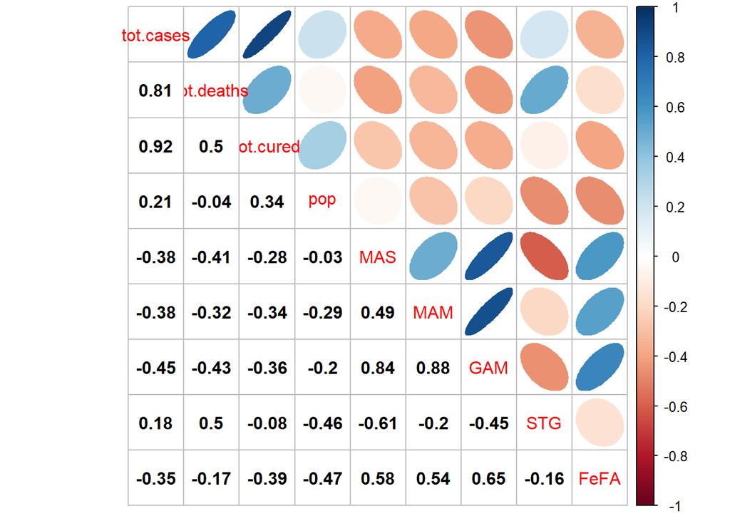

Figure 8: Heatmap

```r
# (1) Code to plot HEATMAP

Cor = cor(congo[unlist(lapply(congo, is.numeric))])
#change col and row names just for readability
v.names <- c('tot.cases','tot.deaths','tot.cured','pop','MAS','MAM','GAM','STG','FeFA')
colnames(Cor) <- v.names
rownames(Cor) <- v.names
corrplot(Cor, type="upper", method="ellipse", tl.pos="d")
corrplot(Cor, type="lower", method="number", col="black",
         add=TRUE, diag=FALSE, tl.pos="n", cl.pos="n")
```

To be more precise, it is actually better to check at the $R^{2}$ (which is the square of the correlation) to have an understanding and to interpret the Pearson coefficient. In fact the $R^{2}_{GAM} \approx 0.19$ meaning that $19%$ of the variance of the dependent variable (**total_deaths**) is explained by **GAM**. It is possible to say the same for the other two considered independent variables, $R^{2}_{STG} = 0.25$ and $R^{2}_{FeFA} = 0.03$.

Standard-non-informative priors have been used for both ($\mu$) and precision($\tau$) which are the two latent variables of the $\beta_{j}$ coefficients.

$$\begin{aligned}
\mu &\sim Normal(0, 10^{-6})\\
\frac{1}{\tau^{2}} &\sim Gamma(10^{-3}, 10^{-3})
\end{aligned}$$

### 2.1) JAGS Model 2

```r
n <- congo$total_cases # tries
r <- congo$total_deaths # number of success (unfortunately...)
GAM <- congo$GAM
STG <- congo$stunted_growth
FeFA <- congo$malnutrition_among_FeFAs
N <- nrow(congo)

congo.jags2 <- list("r", "n", "N","GAM","STG","FeFA")
model2 <- function() {

  # (1) Likelihood
  for(i in 1:N){
    r[i] ~ dbinom(p[i], n[i]) #Model
    logit(p[i]) <- beta[1] + beta[2]*GAM[i] + beta[3]*STG[i] + beta[4]*FeFA[i] #link
  }

  # (2) Priors
  # betas start from 1 and not from 0 to be in concordance with JAGS notation
  for (j in 1:4){ beta[j]~dnorm( mu, tau) }  # pooling

  mu ~ dnorm(0.0, 1e-6) # vague mean Prior -->  there is e-06 since in JAGS it is necessary to pass the PRECISION (which is the inverse of the sd). Lower the Precision higher the SD
  tau ~ dgamma(1e-3, 1e-3) # vague tau (Precision)

  sigma <- 1 / sqrt(tau) # we return the sd that is the inverse squared of the Precision (tau)
  #pop.mean <- exp(mu) / (1 + exp(mu))
}

# Starting values
mod.inits2 = function(){
  list(tau = 1e3,
       mu = 0)
}

# Run JAGS
set.seed(1618216)
mod.fit2 <- jags(data = congo.jags2,
                 model.file = model2, inits = mod.inits2,
                 parameters.to.save = c("p","sigma","mu","tau", "beta"),
                 n.chains = 3, n.iter = 1e4, n.burnin = 1000, n.thin=5)
```

### 2.2) Output & Convergence Diagnostic

```r
mod.fit2
```

```
## Inference for Bugs model at "C:/Users/Francesco/AppData/Local/Temp/RtmpwDw98i/model288cceb5afa.txt", fit using jags,
##  3 chains, each with 10000 iterations (first 1000 discarded), n.thin = 5
##  n.sims = 5400 iterations saved
##           mu.vect sd.vect     2.5%      25%      50%      75%    97.5%  Rhat
## beta[1]    -5.568   0.090   -5.749   -5.630   -5.567   -5.506   -5.398 1.006
## beta[2]     0.121   0.005    0.111    0.118    0.121    0.125    0.132 1.002
## beta[3]     0.085   0.001    0.082    0.084    0.085    0.086    0.088 1.006
## beta[4]     0.292   0.025    0.245    0.275    0.292    0.309    0.342 1.002
## mu         -1.285   2.391   -5.650   -2.341   -1.288   -0.227    3.206 1.002
## p[1]        0.322   0.003    0.316    0.320    0.322    0.324    0.327 1.001
## p[2]        0.541   0.007    0.527    0.536    0.541    0.546    0.555 1.001
## p[3]        0.709   0.005    0.699    0.706    0.709    0.713    0.720 1.004
## p[4]        0.541   0.007    0.527    0.536    0.541    0.546    0.555 1.001
## p[5]        0.322   0.003    0.316    0.320    0.322    0.324    0.327 1.001
## p[6]        0.322   0.003    0.316    0.320    0.322    0.324    0.327 1.001
## p[7]        0.541   0.007    0.527    0.536    0.541    0.546    0.555 1.001
## p[8]        0.322   0.003    0.316    0.320    0.322    0.324    0.327 1.001
## p[9]        0.681   0.005    0.672    0.678    0.681    0.685    0.691 1.001
## p[10]       0.322   0.003    0.316    0.320    0.322    0.324    0.327 1.001
## p[11]       0.752   0.009    0.735    0.746    0.752    0.758    0.769 1.002
## p[12]       0.727   0.005    0.717    0.724    0.727    0.731    0.738 1.004
## p[13]       0.322   0.003    0.316    0.320    0.322    0.324    0.327 1.001
## p[14]       0.322   0.003    0.316    0.320    0.322    0.324    0.327 1.001
## p[15]       0.508   0.006    0.496    0.504    0.508    0.513    0.520 1.002
## p[16]       0.561   0.006    0.549    0.557    0.561    0.565    0.574 1.001
## p[17]       0.581   0.005    0.571    0.578    0.581    0.585    0.592 1.001
## sigma       3.960   2.796    1.624    2.465    3.219    4.473   10.649 1.001
## tau         0.122   0.099    0.009    0.050    0.097    0.165    0.379 1.001
## deviance 4711.057   2.708 4707.626 4709.067 4710.461 4712.381 4717.832 1.008
##          n.eff
## beta[1]    940
## beta[2]   1800
## beta[3]    900
## beta[4]   1800
## mu        5400
## p[1]      5400
## p[2]      5400
## p[3]      1000
## p[4]      5400
## p[5]      5400
## p[6]      5400
## p[7]      5400
## p[8]      5400
## p[9]      5400
## p[10]     5400
## p[11]     2300
## p[12]     1000
## p[13]     5400
## p[14]     5400
## p[15]     2100
## p[16]     5400
## p[17]     5400
## sigma     5400
## tau       5400
## deviance   670
##
## For each parameter, n.eff is a crude measure of effective sample size,
## and Rhat is the potential scale reduction factor (at convergence, Rhat=1).
##
## DIC info (using the rule, pD = var(deviance)/2)
## pD = 3.7 and DIC = 4714.7
## DIC is an estimate of expected predictive error (lower deviance is better).
```

As it is also possible to see from the output table returned by JAGS, the estimated death probabilities per each area are very high unfortunately; meaning that this was actually a letal desease. But where are they coming from? Since it has been used a Binomial with a prob of success $p_{i}$ and the logit of each $p_{i}$ has been modeled as a linear model, this leads to an exponential form equal to:

$$\begin{aligned}
E(y_{i}) &= p_{i} = \frac{e^{\beta_{0} + \sum^{3}_{j=1}\beta_{j}x_{ij}}}{1 +
e^{\beta_{0} + \sum^{3}_{j=1}\beta_{j}x_{ij}} }
\end{aligned}$$

Now, if we invert the *link function* by dividing the numerator and the denominator by the numerator we get a better expression for the $y_{i}$ (which is our dependent variable $p_{i}$):

$$\begin{aligned}
E(y_{i}) &= \frac{1}{1 + e^{-(\beta_{0} + \sum^{3}_{j=1}\beta_{j}x_{ij)}} } \\
E(y_{i}) &= \frac{1}{1 + e^{-(-5.568 + 0.121 \times GAM_{i} + 0.085 \times STG_{i} + 0.292 \times FeFA_{i})} }
\end{aligned}$$

Now, if we substitute each $x_{i}$ with the original values and multiply them by the $\beta_{s}$ coefficients, the results will be the already seen estimated probabilities of death for each region. This is shown by the table reported below:

```r
chainMatrix2 <- mod.fit2$BUGSoutput$sims.matrix # extraxt chains
pm_coeff <- colMeans(chainMatrix2) #posterior mean of the coefficients betas

exp_comp <- function(x1,x2,x3) 1/(1+exp(-(-5.56819741+0.12126469*x1+0.08479912*x2+0.29248419*x3)))
est.probs <- rep(1,N)
for (n in 1:nrow(congo)) est.probs[n] <- exp_comp(congo$GAM[n],congo$stunted_growth[n],congo$malnutrition_among_FeFAs[n])

X = round(cbind('est.probs'=est.probs, 'JAGS.probs' = pm_coeff[7:23]),4)
X <- data.frame(X)
X <- data.frame(t(X))
colnames(X) <- paste("$p_{",seq(1:17),"}$",sep='')

X %>% kbl(caption = 'Table 3: $p_{i}$') %>%
  kable_styling(bootstrap_options = c("striped", "hover", "condensed", "responsive"),full_width = F) %>%
  row_spec(0, background = alpha("orchid",0.2), color = 'black') %>%
  column_spec(1, bold=TRUE) %>%
  scroll_box(width = "830px")
```

Table 3: $p_{i}$

|  | $p_{1}$ | $p_{2}$ | $p_{3}$ | $p_{4}$ | $p_{5}$ | $p_{6}$ | $p_{7}$ | $p_{8}$ | $p_{9}$ | $p_{10}$ | $p_{11}$ | $p_{12}$ | $p_{13}$ | $p_{14}$ | $p_{15}$ | $p_{16}$ | $p_{17}$ |
| --- | --- | --- | --- | --- | --- | --- | --- | --- | --- | --- | --- | --- | --- | --- | --- | --- | --- |
| est.probs | 0.3217 | 0.541 | 0.7095 | 0.541 | 0.3217 | 0.3217 | 0.541 | 0.3217 | 0.6812 | 0.3217 | 0.7521 | 0.7274 | 0.3217 | 0.3217 | 0.5084 | 0.5613 | 0.5815 |
| JAGS.probs | 0.3217 | 0.541 | 0.7095 | 0.541 | 0.3217 | 0.3217 | 0.541 | 0.3217 | 0.6812 | 0.3217 | 0.7520 | 0.7274 | 0.3217 | 0.3217 | 0.5084 | 0.5613 | 0.5814 |

#### 2.2.1) TracePlot & Gelman-Rubin

As it has been done in Diagnostic for Model 1, in order to check if the chains have reached the stationary, different diagnostics have been performed. Also here it is required to extrapolate the **sims.array** from the **JAGS Output** in order to move on.

```r
chainArray2 <- mod.fit2$BUGSoutput$sims.array # get the chain
```

As first, it is always a good starting point to have a look at the **Trace Plots**. It is important to remember that, with this analysis it is possible to see the evolution of the parameter vector over the iterations of the Markov Chains. As shown in **Figure 9**, all the chains, referring to the $\beta_{j}$ coefficients, seem to be exploring the same region of parameter values and this can be inferred by the fact that all the chains lie on top of each other. So, it seems that all the chains have reached stationary.

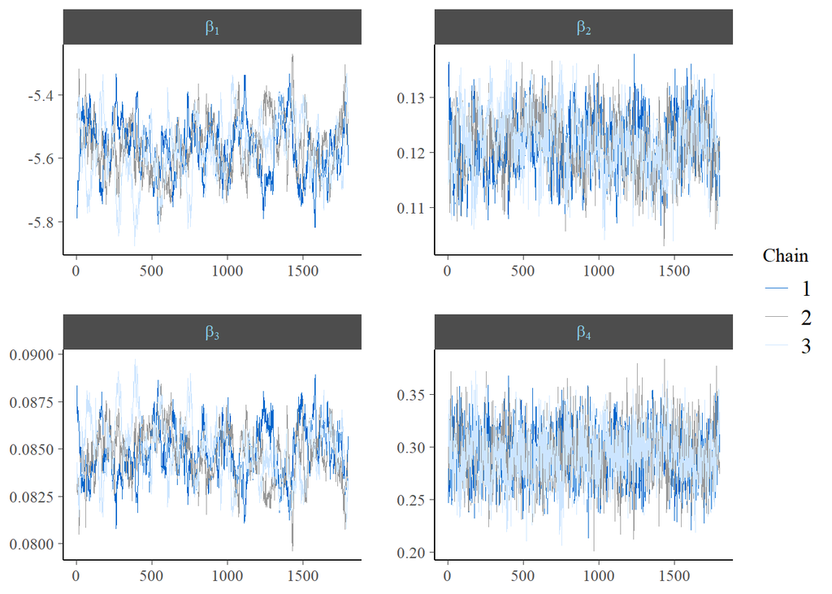

**Figure 9: Trace Plot**

```r
# this is variable is used to change the aspect of some plots.
myfacets <-
  facet_bg(fill = "gray30", color = NA, ) +
  facet_text(face = "bold", color = "skyblue", size = 10)

# (1) mcmc_trace
color_scheme_set("mix-brightblue-gray")
## (1.1) plot 4 betas
mcmc_trace(chainArray2,par=c("beta[1]","beta[2]","beta[3]","beta[4]"),
         facet_args = list(labeller = ggplot2::label_parsed)) +
  myfacets
```

It is also possible to take a look at the **Trace Plots** for the estimated probabilities $p_{i}$ thanks to **FIgure 10**:

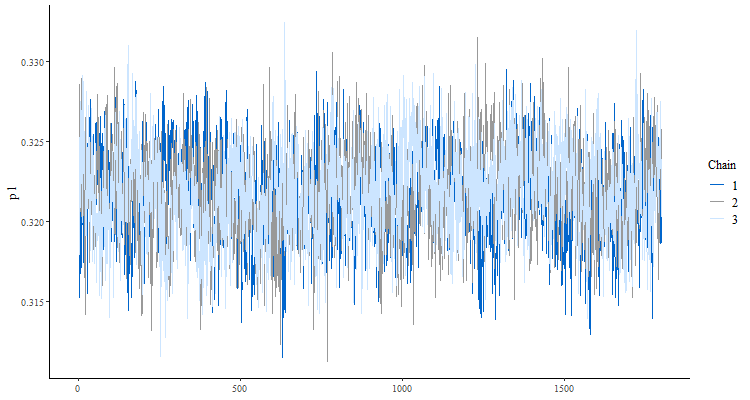

Figure 10: **TracePlot animated GIF**

Also here, since the plot is too confused, it could help our diagnostic to have a closer look at it by using the *“window”* parameter inside the “**mcmc_trace()** function” and see how every chain behaves. As **Figure 11** shows, it seems that the chains spend substantial time in the same region of the parameter space, sign that they are reaching stationary.

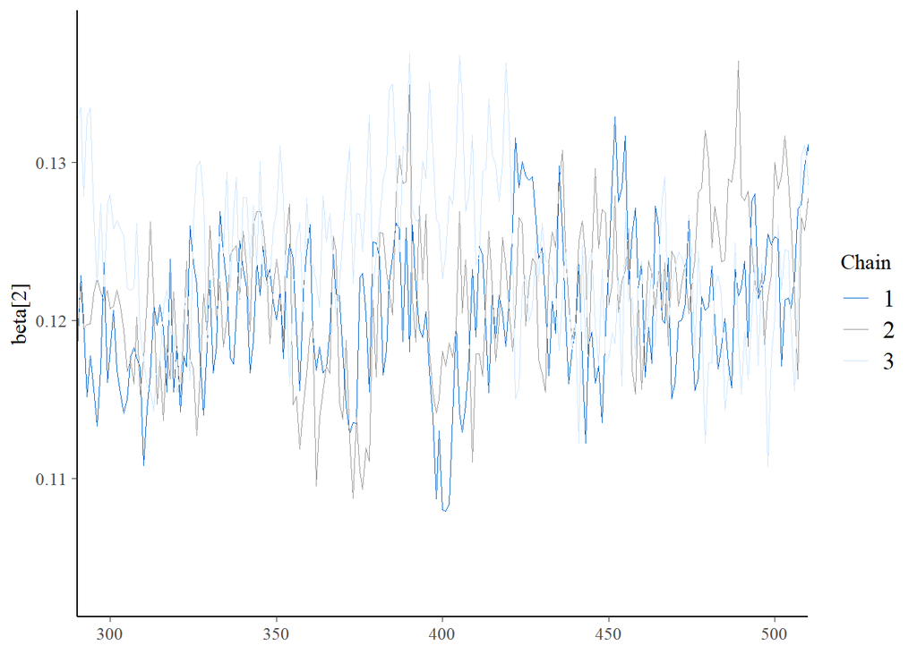

**Figure 11: Beta Window Trace Plot**

```r
mcmc_trace(chainArray2, pars = "beta[2]", window = c(300,500),
           facet_args = list(labeller = ggplot2::label_parsed))+
  myfacets
```

We want to remind that, since Trace PLots provide an informal diagnostic about the convergence of the chains, we could rely on the better diagnostic called **Gelman & Rubin diagnostic**. We can compute this diagnostic by calling the **gelman.diag()** function implemented in coda library. We also remind that the **Potential Scale Factor** is the statistics used to assess convergence (the closer to 1 the better).

```r
coda.fit2 <- as.mcmc(mod.fit2)
gelman.diag(coda.fit2[,c(1:4)])
```

```
## Potential scale reduction factors:
##
##         Point est. Upper C.I.
## beta[1]       1.04       1.13
## beta[2]       1.02       1.06
## beta[3]       1.04       1.12
## beta[4]       1.00       1.02
##
## Multivariate psrf
##
## 1.03
```

As we can see, the chains reached convergence since the values are close to $1$. We can also plot this diagnostic by using the **gelman.plot()** function. It shows how the *“shrinkage factor”* changes once we add iterations to the chains. As we can see also here, after $6000$ we are almost sure to have reached convergence.

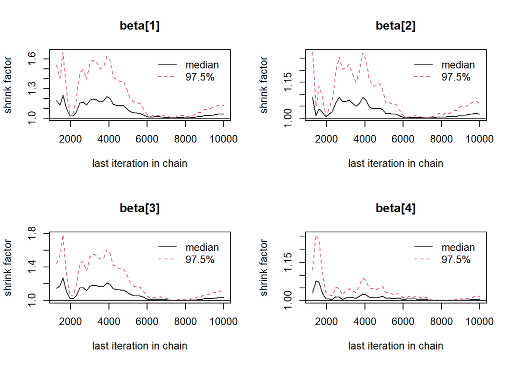

Figure 12: Gelman-Rubin Plot

```r
gelman.plot(coda.fit2[,c(1:4)])
```

It is also possible to take a look at the **Gelman-Rubin Plot** for the estimated probabilities $p_{i}$ by using **FIgure 13**. As can be seen from the animated image, not all the estimated probabilities reached the convergence after $6000$. Some of them required more time.

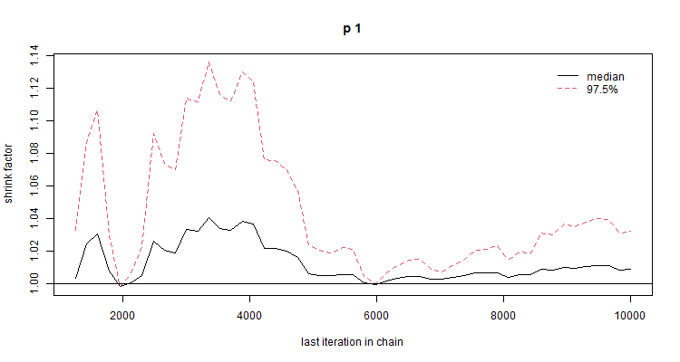

Figure 13: **Gelman-Rubin Plot for $p_{i}$**

#### 2.2.2) Autocorrelation

```r
aut.dat <- round(data.frame(autocorr.diag(coda.fit2)),4)
colnames(aut.dat)[c(1:4,24)] <- c("$\\beta_{1}$","$\\beta_{2}$","$\\beta_{3}$","$\\beta_{4}$","$\\sigma$")
colnames(aut.dat)[c(7:23)] <- paste("$p_{",seq(1:17),"}$",sep='')

aut.dat[,c(1:5,7:23,25,24,6)] %>% kbl(caption='Autoccorelation Diagnostic:') %>%
  kable_styling(bootstrap_options = c("striped", "hover", "condensed", "responsive"),full_width = F) %>%
  row_spec(0, background = alpha("orchid",0.2), color = 'black') %>%
  column_spec(1, bold=T,width = "80px") %>%
  scroll_box(width = "830px")
```

Autoccorelation Diagnostic:

|  | $\beta_{1}$ | $\beta_{2}$ | $\beta_{3}$ | $\beta_{4}$ | deviance | $p_{1}$ | $p_{2}$ | $p_{3}$ | $p_{4}$ | $p_{5}$ | $p_{6}$ | $p_{7}$ | $p_{8}$ | $p_{9}$ | $p_{10}$ | $p_{11}$ | $p_{12}$ | $p_{13}$ | $p_{14}$ | $p_{15}$ | $p_{16}$ | $p_{17}$ | tau | $\sigma$ | mu |
| --- | --- | --- | --- | --- | --- | --- | --- | --- | --- | --- | --- | --- | --- | --- | --- | --- | --- | --- | --- | --- | --- | --- | --- | --- | --- |
| Lag 0 | 1.0000 | 1.0000 | 1.0000 | 1.0000 | 1.0000 | 1.0000 | 1.0000 | 1.0000 | 1.0000 | 1.0000 | 1.0000 | 1.0000 | 1.0000 | 1.0000 | 1.0000 | 1.0000 | 1.0000 | 1.0000 | 1.0000 | 1.0000 | 1.0000 | 1.0000 | 1.0000 | 1.0000 | 1.0000 |
| Lag 5 | 0.9540 | 0.6694 | 0.9430 | 0.3295 | 0.2695 | 0.2687 | 0.2687 | 0.5976 | 0.6440 | 0.2687 | 0.2687 | 0.3486 | 0.2048 | 0.1526 | 0.2509 | 0.6148 | 0.2509 | 0.2687 | 0.2687 | 0.2509 | 0.2687 | 0.2369 | 0.0104 | -0.0148 | -0.0150 |
| Lag 25 | 0.7987 | 0.3384 | 0.7765 | 0.1371 | 0.1345 | 0.1651 | 0.1651 | 0.2906 | 0.4597 | 0.1651 | 0.1651 | 0.1691 | 0.0046 | 0.0071 | 0.0030 | 0.4271 | 0.0030 | 0.1651 | 0.1651 | 0.0030 | 0.1651 | 0.0185 | -0.0109 | 0.0025 | 0.0221 |
| Lag 50 | 0.6432 | 0.2663 | 0.6277 | 0.1071 | 0.0647 | 0.1253 | 0.1253 | 0.2328 | 0.3818 | 0.1253 | 0.1253 | 0.1244 | 0.0134 | 0.0164 | 0.0109 | 0.3562 | 0.0109 | 0.1253 | 0.1253 | 0.0109 | 0.1253 | 0.0143 | -0.0163 | -0.0012 | -0.0023 |
| Lag 250 | 0.1129 | 0.0547 | 0.1007 | 0.0038 | -0.0192 | 0.0280 | 0.0280 | 0.0467 | 0.0481 | 0.0280 | 0.0280 | 0.0175 | -0.0108 | -0.0094 | -0.0115 | 0.0432 | -0.0115 | 0.0280 | 0.0280 | -0.0115 | 0.0280 | 0.0003 | 0.0219 | -0.0096 | 0.0070 |

As it has been pointed out in the previous section, autocorrelation is very important since it assesses how much information is available in each Markov chain.

It is possible to visualize the autocorrelation by calling the **mcmc_acf()** function. This function shows the autocorrelation for each Markov chain separately up to a user-defined number of lags. What is expected to see it is a low autocorrelation since it is a signal of convergence.

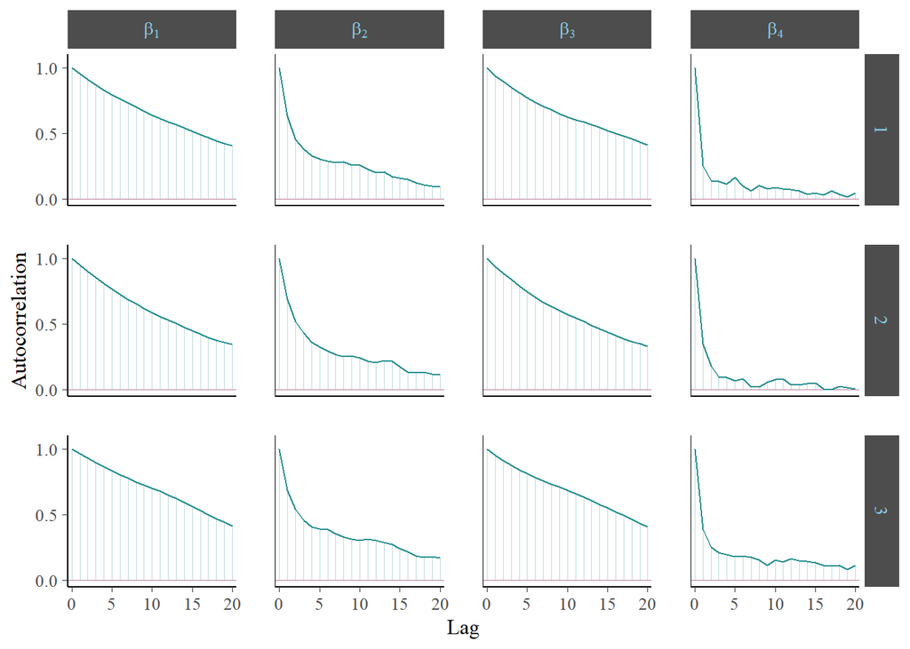

```r
# (2) mcmc_acf
color_scheme_set("mix-teal-pink") # set color
## (2.1) plot 4 betas
mcmc_acf(chainArray2,par=c("beta[1]","beta[2]","beta[3]","beta[4]"),
         facet_args = list(labeller = ggplot2::label_parsed))+
  myfacets
```

#### 2.2.3) Posterior Distributions

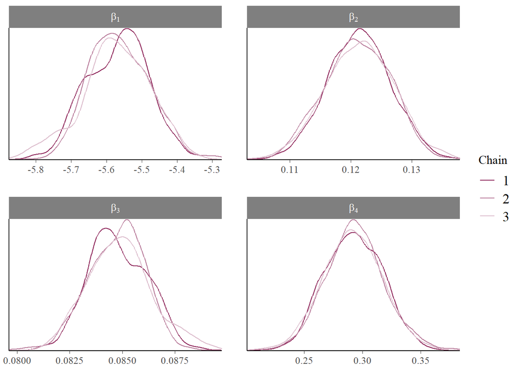

**Figure 16: Density Overlay Plot for Betas**

```r
# (3) mcmc_density
color_scheme_set("pink")
## (3.1) plot 4 betas
myfacets <-
  facet_bg(fill = "gray50", color = NA, ) +
  facet_text(face = "bold", color = 'white', size = 10)

mcmc_dens_overlay(chainArray2,par=c("beta[1]","beta[2]","beta[3]","beta[4]"),
           facet_args = list(labeller = ggplot2::label_parsed)) +
  myfacets
```

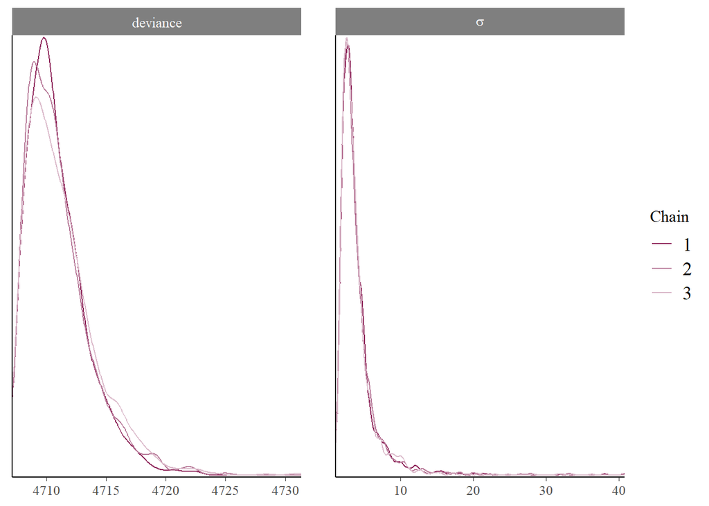

**Figure 17: Density Overlay Plot for Deviance and Sigma**

[figure not shown]

```r
## (3.2) plot deviance and sigma
mcmc_dens_overlay(chainArray2,par=c("deviance","sigma"),
           facet_args = list(labeller = ggplot2::label_parsed)) +
  myfacets
```

Here below are also reported the posterior distributions with 90% Credibility intervals.

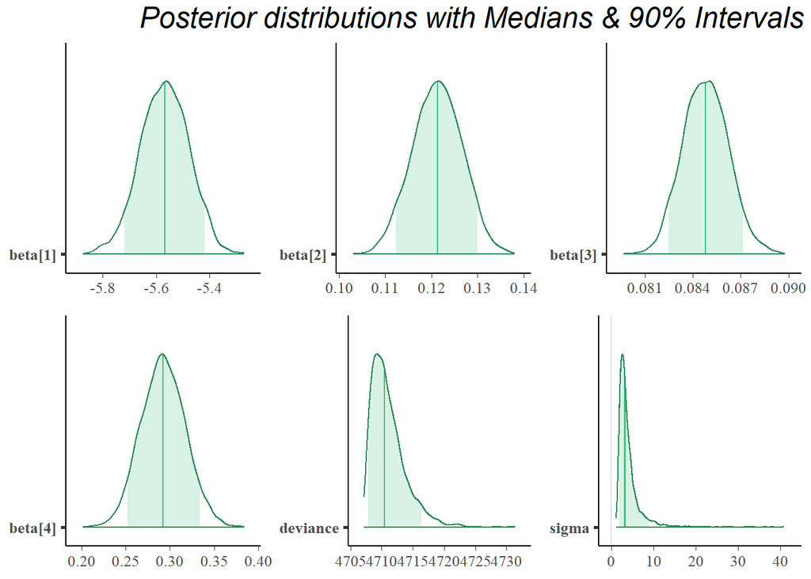

Figure 16: Posterior Density Plots with Medians and Intervals

```r
# (4) areas plot

color_scheme_set("green")
b1 <- mcmc_areas(chainArray2,
           pars=c("beta[1]"),
           prob = 0.9, point_est = 'median')
b2 <- mcmc_areas(chainArray2,
           pars=c("beta[2]"),
           prob = 0.9, point_est = 'median')
b3 <- mcmc_areas(chainArray2,
           pars=c("beta[3]"),
           prob = 0.9, point_est = 'median')
b4 <- mcmc_areas(chainArray2,
           pars=c("beta[4]"),
           prob = 0.9, point_est = 'median')
dev <- mcmc_areas(chainArray2,
           pars=c("deviance"),
           prob = 0.9, point_est = 'median')
sig <- mcmc_areas(chainArray2,
           pars=c("sigma"),
           prob = 0.9, point_est = 'median')
fig <- ggarrange(b1, b2,
          b3, b4,
          dev, sig,
          ncol = 3, nrow = 2)
annotate_figure(fig, top = text_grob(
  "Posterior distributions with Medians & 90% Intervals",
  color = "black",hjust = 1.01, x = 1,
  face = "italic", size = 18))
```

### 2.3) Credibility Intervals Model 2

Let’s compute the point estimates for the $p_{i}$

```r
chainMatrix2 <- mod.fit2$BUGSoutput$sims.matrix # join the deviance and pi for all the 3 chains

p.hat.jags2 <- colMeans(chainMatrix2)
p.hat.jags2
```

```
##       beta[1]       beta[2]       beta[3]       beta[4]      deviance
##   -5.56819741    0.12126469    0.08479912    0.29248419 4711.05665676
##            mu          p[1]          p[2]          p[3]          p[4]
##   -1.28454752    0.32173363    0.54095854    0.70947656    0.54095854
##          p[5]          p[6]          p[7]          p[8]          p[9]
##    0.32173363    0.32173363    0.54095854    0.32173363    0.68118967
##         p[10]         p[11]         p[12]         p[13]         p[14]
##    0.32173363    0.75203263    0.72735880    0.32173363    0.32173363
##         p[15]         p[16]         p[17]         sigma           tau
##    0.50842668    0.56130240    0.58144315    3.96037819    0.12164898
```

Now these results can be used to compute _Credibility Intervals, both equal tails and HPD (Highest Posterior Density)

**Equal Tail & HPD Intervals:**

```r
cred <- 0.95
p.ET.jags2 <- apply(chainMatrix2, 2, quantile, prob=c((1-cred)/2, 1-(1-cred)/2))
p.HPD.jags2 <- HPDinterval(as.mcmc(chainMatrix2))
```

```r
res.dat2 <- data.frame('ET2.5'=p.ET.jags2[1,],
                      'ET97.5'=p.ET.jags2[2,],
                      'HPD2.5'=p.HPD.jags2[,1],
                      'HPD97.5'=p.HPD.jags2[,2])

row.names(res.dat2)[c(1:4,6,24,25)] <- c(paste("\\beta_{",seq(1:4),"}$",sep=''),"$\\mu","$\\sigma$","$\\tau")
row.names(res.dat2)[c(7:23)] <- paste("$p_{",seq(1:17),"}$",sep='')


my.colors <- c('white',rep('royalblue',2),rep('yellow',2)) # set colors

kbl(round(res.dat2[c(1:5,7:23,25,24,6),],4),col.names = NULL,
    caption="     95% Intervals:") %>%
  kable_styling(bootstrap_options = c("striped", "hover", "condensed", "responsive")) %>%
  add_header_above(c(" ", "Lower" = 1, "Upper" = 1, "Lower" = 1, "Upper" = 1),
                   bold = T, background = alpha(my.colors, 0.05), color = 'red') %>%
  add_header_above(c(" ", "Equal Tail" = 2, "HPD" = 2),
                   background = alpha(my.colors[c(1:2,4)],0.05), color = 'black') %>%
  column_spec(c(2,3), background = alpha(my.colors[2], 0.05)) %>%
  column_spec(c(4,5), background = alpha(my.colors[4], 0.05)) %>%
  scroll_box(height = "400px")
```

95% Intervals:

[output not shown]

## Model Comparison

In order to compare models it is possible to use the DIC (Deviance Information Criterion) metric. DIC is a Bayesian method for model comparison and a measure for the prediction error of a model. The lower DIC value the better the model fits the data, [DIC](https://rss.onlinelibrary.wiley.com/doi/pdf/10.1111/1467-9868.00353).

The deviance D, given a parameter value $\theta$ returns error using the log-likelihood function: $D(\theta) = -2 \text{log} * L(data|\theta)$

Once the posterior means are computed, it is possible to measure the deviance as:

$D(\hat{\theta}) = -2 \text{log} * L(data|\hat{\theta})$ Taking all $i$ steps in the different MCMCs, it is possible to compute an average - posterior mean of the deviance as follows:

$\hat{D} = \frac{1}{M}\sum^{M}_{i=1}D (\theta_{i})$

Now it is possible to compute the effective number of parameters:

$p_{D} = \hat{D} - D(\hat{\theta})$

The DIC is then computed:

```r
cat(
  paste("- `", "Model 1 DIC: ",round(mod.fit$BUGSoutput$DIC, 3), "`"),
  paste("- `", "Model 2 DIC: ",round(mod.fit2$BUGSoutput$DIC, 3), "`"),
  sep='\n'
)
```

- `Model 1 DIC: 10090.458`
- `Model 2 DIC: 4714.713`

Looking at the DIC values, it is clearly shown that there is a significant difference among the models. For that reason, it is possible to assess that Model 2 is preferable over Model 1. In fact, the DIC difference is equal to:

```r
cat(paste("`", "DIC Difference:", round(abs(mod.fit$BUGSoutput$DIC - mod.fit2$BUGSoutput$DIC),3),"`"))
```

`DIC Difference: 5375.745`

## Appendix A

$$ACF(X_{t},X_{t-l}) = \frac{Cov(X_{t},X_{t-l})}{\sqrt{Var(X_{t}) \times Var(X_{t-l})}}$$

If the sequence is stationary (as it is), the joint distribution of multiple Xs doesn’t change with time shifts, then autocorrelation for two variables doesn’t depend on the exact times $t$ and $t-l$ but rather on the distance between them: $l$. This is the reason why the autocorrelation plots are computed in terms of lags. Font: Autocorrelation

## Appendix B

Here below is reported the code used to create the GIFs and save them:

```r
# DENSITY PLOT GIF
setwd("C:/Users/Francesco/Desktop/Bayesian-Analysis-using-MCMC-simulation-with-JAGS/images")
color_scheme_set("pink")

saveGIF ({
  # (3) mcmc_trace
  for (m in 1:N){
    plot(mcmc_dens_overlay(chainArray2,par=c(paste("p[",m,"]",sep='')),
                           facet_args = list(labeller = ggplot2::label_parsed)) +
           xlab(paste('p',m)))
    Sys.sleep(1)
  }
}, ani.height = 400, ani.width =750, movie.name = "pi_density.gif")

# GELMAN RUBIN GIF

saveGIF ({
  # (3) Gelman-Rubin
  for (m in 1:N){
    gelman.plot(coda.fit2[,paste("p[",m,"]",sep='')], main=paste('p',m))
    Sys.sleep(1)
  }
}, ani.height = 400, ani.width =750, movie.name = "Gelman_Rubin_plot.gif")


# TRACE PLOT GIF

color_scheme_set("mix-brightblue-gray")
saveGIF ({
  # (3) mcmc_trace
  for (m in 1:N){
    plot(mcmc_trace(chainArray2,par=c(paste("p[",m,"]",sep='')),
                    facet_args = list(labeller = ggplot2::label_parsed))+
           ylab(paste('p',m)) )
    Sys.sleep(1)
  }
}, ani.height = 400, ani.width =750, movie.name = "pi_traceplot.gif")
```